##### Title: **A Simulation Exercise for Exponential Distribution and Central Limit Theorem**

##### Author: **Thomas Ng Jia Chee**

##### Date: **20 October 2015**

## Overview

This simulation aims to investigate the exponential distribution in R and compare it with Central Limit Theorem. The exponential distribution is the probability distribution that describes the time between events in a Poisson process.

**Mean = Standard Deviation = lambda^(-1)**

Central Limit Theorem states that, when sufficient large number of iterates of independent random variables, the result will be approximately normally distributed, regardless of the underlying distribution.

**In this simulation lambda is set at *0.2*, sample size is *40* and number of simulation (sampling) is *1000*.**

## Simulation

```r
# set lambda
lambda <- 0.2

# set number of observation (sample size)
n <- 40

# set number of simualtion (sampling)
count <- 1000

# simulate exponential distribution of 'n' samples a 'count' times
exp_dist_simulation <- replicate(count, rexp(n, lambda))

# apply function 'mean' to 'exp_dist_simulation', 2 represents column
# also called Sampling Distribution of the Sample Mean
sample_mean <- apply(exp_dist_simulation, 2, mean)
```

## Result of simulation

In theory, both mean and standard deviation of this expoenential distribution simulation should be *1/lambda (0.2)* which is *5*.

Let’s find out if simulation result matches theory.

```r
# mean of Sampling Distribution of the Sample Mean (mean of means)
# is it 5 ?
mean(sample_mean)
```

```
## [1] 5.010103
```

```r
# standard deviation of Sampling Distribution of the Sample Mean
# aka Standard Error
# is it 0.79 ?
sd(sample_mean)
```

```
## [1] 0.7949887
```

```r
# variance, is it 0.62 (0.79^2) ?
var(sample_mean)
```

```
## [1] 0.632007
```

Central limit theorem states that the result would be normally distributed.

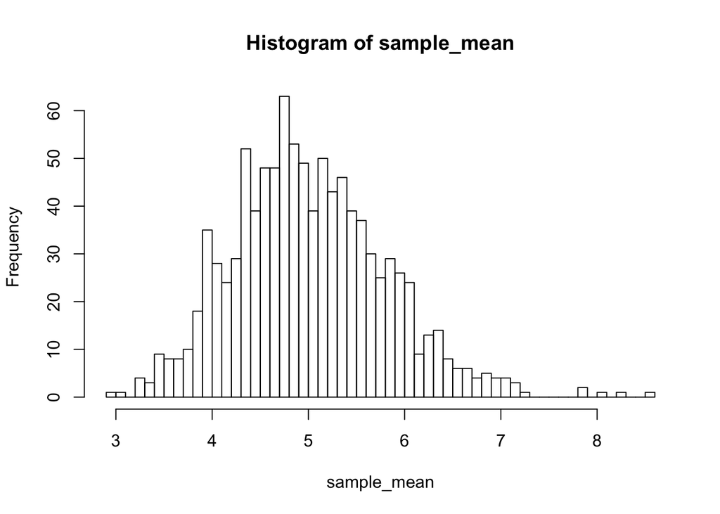

```r
# is it normally distributed ?
hist(sample_mean, breaks=40)
```

**In conclusion, this simulation supports central limit theorem. The simulation results are significantly close to theoretical mean and variance. In addition, the sampling distribution is normally distributed, regardless of the underlying distribution.**